# Project: Wrangling and Analyze Data

#### Updating pandas

```python
!pip install --upgrade pandas
```

[output not shown]

#### Importing Needed Lilbraries

```python
import pandas as pd
import numpy as np
import requests as rq
import matplotlib.pyplot as plt
%matplotlib inline
```

## Data Gathering

In the cell below, gather **all** three pieces of data for this project and load them in the notebook. **Note:** the methods required to gather each data are different.

1. Directly download the WeRateDogs Twitter archive data (twitter_archive_enhanced.csv)

#### Loading twitter arichive to pandas dataframe

```python
twitter_archive_df = pd.read_csv('twitter-archive-enhanced.csv')
```

#### Test:

```python
twitter_archive_df.info()
```

```
<class 'pandas.core.frame.DataFrame'>
RangeIndex: 2356 entries, 0 to 2355
Data columns (total 17 columns):
 #   Column                      Non-Null Count  Dtype
---  ------                      --------------  -----
 0   tweet_id                    2356 non-null   int64
 1   in_reply_to_status_id       78 non-null     float64
 2   in_reply_to_user_id         78 non-null     float64
 3   timestamp                   2356 non-null   object
 4   source                      2356 non-null   object
 5   text                        2356 non-null   object
 6   retweeted_status_id         181 non-null    float64
 7   retweeted_status_user_id    181 non-null    float64
 8   retweeted_status_timestamp  181 non-null    object
 9   expanded_urls               2297 non-null   object
 10  rating_numerator            2356 non-null   int64
 11  rating_denominator          2356 non-null   int64
 12  name                        2356 non-null   object
 13  doggo                       2356 non-null   object
 14  floofer                     2356 non-null   object
 15  pupper                      2356 non-null   object
 16  puppo                       2356 non-null   object
dtypes: float64(4), int64(3), object(10)
memory usage: 313.0+ KB
```

```python
twitter_archive_df.head()
```

|  | tweet_id | in_reply_to_status_id | in_reply_to_user_id | timestamp | source | text | retweeted_status_id | retweeted_status_user_id | retweeted_status_timestamp | expanded_urls | rating_numerator | rating_denominator | name | doggo | floofer | pupper | puppo |
| --- | --- | --- | --- | --- | --- | --- | --- | --- | --- | --- | --- | --- | --- | --- | --- | --- | --- |
| 0 | 892420643555336193 | NaN | NaN | 2017-08-01 16:23:56 +0000 | <a href="http://twitter.com/download/iphone" r... | This is Phineas. He's a mystical boy. Only eve... | NaN | NaN | NaN | https://twitter.com/dog_rates/status/892420643... | 13 | 10 | Phineas | None | None | None | None |
| 1 | 892177421306343426 | NaN | NaN | 2017-08-01 00:17:27 +0000 | <a href="http://twitter.com/download/iphone" r... | This is Tilly. She's just checking pup on you.... | NaN | NaN | NaN | https://twitter.com/dog_rates/status/892177421... | 13 | 10 | Tilly | None | None | None | None |
| 2 | 891815181378084864 | NaN | NaN | 2017-07-31 00:18:03 +0000 | <a href="http://twitter.com/download/iphone" r... | This is Archie. He is a rare Norwegian Pouncin... | NaN | NaN | NaN | https://twitter.com/dog_rates/status/891815181... | 12 | 10 | Archie | None | None | None | None |
| 3 | 891689557279858688 | NaN | NaN | 2017-07-30 15:58:51 +0000 | <a href="http://twitter.com/download/iphone" r... | This is Darla. She commenced a snooze mid meal... | NaN | NaN | NaN | https://twitter.com/dog_rates/status/891689557... | 13 | 10 | Darla | None | None | None | None |
| 4 | 891327558926688256 | NaN | NaN | 2017-07-29 16:00:24 +0000 | <a href="http://twitter.com/download/iphone" r... | This is Franklin. He would like you to stop ca... | NaN | NaN | NaN | https://twitter.com/dog_rates/status/891327558... | 12 | 10 | Franklin | None | None | None | None |

1. Use the Requests library to download the tweet image prediction (image_predictions.tsv)

#### Downloading image_predictions.tsv

#### Storing image predictions url and file format to two variables

```python
image_predictions_url = 'https://d17h27t6h515a5.cloudfront.net/topher/2017/August/599fd2ad_image-predictions/image-predictions.tsv' #Url
image_predictions_query_parameter = {'downlaodformat':'tsv'} #File Format
```

```python
image_predictions_response = rq.get(image_predictions_url , params=image_predictions_query_parameter)
```

```python
with open('image_predictions.tsv', 'wb') as image_predictions_file:
    image_predictions_file.write(image_predictions_response.content)
```

#### Loading the dataset

```python
image_predictions_df = pd.read_csv('image_predictions.tsv' , sep = '\t')
```

#### Test:

```python
image_predictions_df.info()
```

```
<class 'pandas.core.frame.DataFrame'>
RangeIndex: 2075 entries, 0 to 2074
Data columns (total 12 columns):
 #   Column    Non-Null Count  Dtype
---  ------    --------------  -----
 0   tweet_id  2075 non-null   int64
 1   jpg_url   2075 non-null   object
 2   img_num   2075 non-null   int64
 3   p1        2075 non-null   object
 4   p1_conf   2075 non-null   float64
 5   p1_dog    2075 non-null   bool
 6   p2        2075 non-null   object
 7   p2_conf   2075 non-null   float64
 8   p2_dog    2075 non-null   bool
 9   p3        2075 non-null   object
 10  p3_conf   2075 non-null   float64
 11  p3_dog    2075 non-null   bool
dtypes: bool(3), float64(3), int64(2), object(4)
memory usage: 152.1+ KB
```

```python
image_predictions_df.head()
```

|  | tweet_id | jpg_url | img_num | p1 | p1_conf | p1_dog | p2 | p2_conf | p2_dog | p3 | p3_conf | p3_dog |
| --- | --- | --- | --- | --- | --- | --- | --- | --- | --- | --- | --- | --- |
| 0 | 666020888022790149 | https://pbs.twimg.com/media/CT4udn0WwAA0aMy.jpg | 1 | Welsh_springer_spaniel | 0.465074 | True | collie | 0.156665 | True | Shetland_sheepdog | 0.061428 | True |
| 1 | 666029285002620928 | https://pbs.twimg.com/media/CT42GRgUYAA5iDo.jpg | 1 | redbone | 0.506826 | True | miniature_pinscher | 0.074192 | True | Rhodesian_ridgeback | 0.072010 | True |
| 2 | 666033412701032449 | https://pbs.twimg.com/media/CT4521TWwAEvMyu.jpg | 1 | German_shepherd | 0.596461 | True | malinois | 0.138584 | True | bloodhound | 0.116197 | True |
| 3 | 666044226329800704 | https://pbs.twimg.com/media/CT5Dr8HUEAA-lEu.jpg | 1 | Rhodesian_ridgeback | 0.408143 | True | redbone | 0.360687 | True | miniature_pinscher | 0.222752 | True |
| 4 | 666049248165822465 | https://pbs.twimg.com/media/CT5IQmsXIAAKY4A.jpg | 1 | miniature_pinscher | 0.560311 | True | Rottweiler | 0.243682 | True | Doberman | 0.154629 | True |

1. Use the Tweepy library to query additional data via the Twitter API (tweet_json.txt)

#### Importing tweet_json.txt to pandas dataframe

```python
tweet_json_response = rq.get('https://video.udacity-data.com/topher/2018/November/5bf60fda_tweet-json/tweet-json')
```

```python
with open('tweet_json.txt','wb') as tweet_json_file:
    tweet_json_file.write(tweet_json_response.content)
```

```python
tweet_json_df = pd.read_json('tweet_json.txt',lines= True)
```

#### Test:

```python
tweet_json_df.info() #checking our dataset
```

```
<class 'pandas.core.frame.DataFrame'>
RangeIndex: 2354 entries, 0 to 2353
Data columns (total 31 columns):
 #   Column                         Non-Null Count  Dtype
---  ------                         --------------  -----
 0   created_at                     2354 non-null   datetime64[ns, UTC]
 1   id                             2354 non-null   int64
 2   id_str                         2354 non-null   int64
 3   full_text                      2354 non-null   object
 4   truncated                      2354 non-null   bool
 5   display_text_range             2354 non-null   object
 6   entities                       2354 non-null   object
 7   extended_entities              2073 non-null   object
 8   source                         2354 non-null   object
 9   in_reply_to_status_id          78 non-null     float64
```

[output cut: 23 more lines]

#### Renaming id column to tweet_id to merging these three datasets in twitter_archive_master

```python
tweet_json_df.rename(columns={'id': 'tweet_id'}, inplace=True) #Renaming id column to tweet_id
```

```python
tweet_json_df.columns
```

```
Index(['created_at', 'tweet_id', 'id_str', 'full_text', 'truncated',
       'display_text_range', 'entities', 'extended_entities', 'source',
       'in_reply_to_status_id', 'in_reply_to_status_id_str',
       'in_reply_to_user_id', 'in_reply_to_user_id_str',
       'in_reply_to_screen_name', 'user', 'geo', 'coordinates', 'place',
       'contributors', 'is_quote_status', 'retweet_count', 'favorite_count',
       'favorited', 'retweeted', 'possibly_sensitive',
       'possibly_sensitive_appealable', 'lang', 'retweeted_status',
       'quoted_status_id', 'quoted_status_id_str', 'quoted_status'],
      dtype='object')
```

#### Merging three dataset in one dataset (twitter_archive_master) DataFrame

```python
twitter_archive_master = pd.merge(pd.merge(twitter_archive_df, image_predictions_df, on='tweet_id'), tweet_json_df, on='tweet_id')
```

```python
twitter_archive_master.head(2)
```

|  | tweet_id | in_reply_to_status_id_x | in_reply_to_user_id_x | timestamp | source_x | text | retweeted_status_id | retweeted_status_user_id | retweeted_status_timestamp | expanded_urls | ... | favorite_count | favorited | retweeted | possibly_sensitive | possibly_sensitive_appealable | lang | retweeted_status | quoted_status_id | quoted_status_id_str | quoted_status |
| --- | --- | --- | --- | --- | --- | --- | --- | --- | --- | --- | --- | --- | --- | --- | --- | --- | --- | --- | --- | --- | --- |
| 0 | 892420643555336193 | NaN | NaN | 2017-08-01 16:23:56 +0000 | <a href="http://twitter.com/download/iphone" r... | This is Phineas. He's a mystical boy. Only eve... | NaN | NaN | NaN | https://twitter.com/dog_rates/status/892420643... | ... | 39467 | False | False | 0.0 | 0.0 | en | NaN | NaN | NaN | NaN |
| 1 | 892177421306343426 | NaN | NaN | 2017-08-01 00:17:27 +0000 | <a href="http://twitter.com/download/iphone" r... | This is Tilly. She's just checking pup on you.... | NaN | NaN | NaN | https://twitter.com/dog_rates/status/892177421... | ... | 33819 | False | False | 0.0 | 0.0 | en | NaN | NaN | NaN | NaN |

2 rows × 58 columns

#### Making max_columns display to 58

```python
pd.set_option('display.max_columns', 58)
```

#### Test:

```python
twitter_archive_master.sample(5)
```

|  | tweet_id | in_reply_to_status_id_x | in_reply_to_user_id_x | timestamp | source_x | text | retweeted_status_id | retweeted_status_user_id | retweeted_status_timestamp | expanded_urls | rating_numerator | rating_denominator | name | doggo | floofer | pupper | puppo | jpg_url | img_num | p1 | p1_conf | p1_dog | p2 | p2_conf | p2_dog | p3 | p3_conf | p3_dog | created_at | … |
| --- | --- | --- | --- | --- | --- | --- | --- | --- | --- | --- | --- | --- | --- | --- | --- | --- | --- | --- | --- | --- | --- | --- | --- | --- | --- | --- | --- | --- | --- | --- |
| 66 | 877736472329191424 | NaN | NaN | 2017-06-22 03:54:17 +0000 | <a href="http://twitter.com/download/iphone" r... | This is Aja. She was just told she's a good do... | NaN | NaN | NaN | https://twitter.com/dog_rates/status/877736472... | 13 | 10 | Aja | None | None | None | None | https://pbs.twimg.com/media/DC5YqoQW0AArOLH.jpg | 2 | Chesapeake_Bay_retriever | 0.837956 | True | Labrador_retriever | 0.062034 | True | Weimaraner | 0.040599 | True | 2017-06-22 03:54:17+00:00 | … |
| 1203 | 697616773278015490 | NaN | NaN | 2016-02-11 03:02:54 +0000 | <a href="http://twitter.com/download/iphone" r... | This pupper doubles as a hallway rug. Very rar... | NaN | NaN | NaN | https://twitter.com/dog_rates/status/697616773... | 11 | 10 | None | None | None | pupper | None | https://pbs.twimg.com/media/Ca5uv7RVAAA_QEg.jpg | 1 | Lhasa | 0.521931 | True | Shih-Tzu | 0.403451 | True | Tibetan_terrier | 0.039912 | True | 2016-02-11 03:02:54+00:00 | … |
| 1075 | 708356463048204288 | NaN | NaN | 2016-03-11 18:18:36 +0000 | <a href="http://twitter.com/download/iphone" r... | This is Oliver. That is his castle. He protect... | NaN | NaN | NaN | https://twitter.com/dog_rates/status/708356463... | 10 | 10 | Oliver | None | None | None | None | https://pbs.twimg.com/media/CdSWcc1XIAAXc6H.jpg | 2 | pug | 0.871283 | True | French_bulldog | 0.041820 | True | bath_towel | 0.015228 | False | 2016-03-11 18:18:36+00:00 | … |
| 726 | 759197388317847553 | NaN | NaN | 2016-07-30 01:22:17 +0000 | <a href="http://twitter.com/download/iphone" r... | This is Luna. She's just heckin precious af I ... | NaN | NaN | NaN | https://twitter.com/dog_rates/status/759197388... | 12 | 10 | Luna | None | None | None | None | https://pbs.twimg.com/media/Cok1_sjXgAU3xpp.jpg | 1 | kuvasz | 0.511341 | True | golden_retriever | 0.076899 | True | white_wolf | 0.063269 | False | 2016-07-30 01:22:17+00:00 | … |
| 317 | 825026590719483904 | NaN | NaN | 2017-01-27 17:04:02 +0000 | <a href="http://twitter.com/download/iphone" r... | Say hello to Pablo. He's one gorgeous puppo. A... | NaN | NaN | NaN | https://www.gofundme.com/my-puppys-double-cata... | 12 | 10 | Pablo | None | None | None | puppo | https://pbs.twimg.com/media/C3MVTeHWcAAGNfx.jpg | 2 | Eskimo_dog | 0.524454 | True | Siberian_husky | 0.467678 | True | malamute | 0.004976 | True | 2017-01-27 17:04:02+00:00 | … |

```python
twitter_archive_master.info()
```

```
<class 'pandas.core.frame.DataFrame'>
Int64Index: 2073 entries, 0 to 2072
Data columns (total 58 columns):
 #   Column                         Non-Null Count  Dtype
---  ------                         --------------  -----
 0   tweet_id                       2073 non-null   int64
 1   in_reply_to_status_id_x        23 non-null     float64
 2   in_reply_to_user_id_x          23 non-null     float64
 3   timestamp                      2073 non-null   object
 4   source_x                       2073 non-null   object
 5   text                           2073 non-null   object
 6   retweeted_status_id            79 non-null     float64
 7   retweeted_status_user_id       79 non-null     float64
 8   retweeted_status_timestamp     79 non-null     object
 9   expanded_urls                  2073 non-null   object
```

[output cut: 50 more lines]

## Assessing Data

In this section, detect and document at least **eight (8) quality issues and two (2) tidiness issue**. You must use **both** visual assessment programmatic assessement to assess the data.

**Note:** pay attention to the following key points when you access the data.

- You only want original ratings (no retweets) that have images. Though there are 5000+ tweets in the dataset, not all are dog ratings and some are retweets.
- Assessing and cleaning the entire dataset completely would require a lot of time, and is not necessary to practice and demonstrate your skills in data wrangling. Therefore, the requirements of this project are only to assess and clean at least 8 quality issues and at least 2 tidiness issues in this dataset.
- The fact that the rating numerators are greater than the denominators does not need to be cleaned. This [unique rating system](http://knowyourmeme.com/memes/theyre-good-dogs-brent) is a big part of the popularity of WeRateDogs.
- You do not need to gather the tweets beyond August 1st, 2017. You can, but note that you won't be able to gather the image predictions for these tweets since you don't have access to the algorithm used.

```python
twitter_archive_master.info()
```

```
<class 'pandas.core.frame.DataFrame'>
Int64Index: 2073 entries, 0 to 2072
Data columns (total 58 columns):
 #   Column                         Non-Null Count  Dtype
---  ------                         --------------  -----
 0   tweet_id                       2073 non-null   int64
 1   in_reply_to_status_id_x        23 non-null     float64
 2   in_reply_to_user_id_x          23 non-null     float64
 3   timestamp                      2073 non-null   object
 4   source_x                       2073 non-null   object
 5   text                           2073 non-null   object
 6   retweeted_status_id            79 non-null     float64
 7   retweeted_status_user_id       79 non-null     float64
 8   retweeted_status_timestamp     79 non-null     object
 9   expanded_urls                  2073 non-null   object
```

[output cut: 50 more lines]

- tweet_id should be object
- There are columns have many null values

#### Displaying columns unique values

```python
def display_unique_values(df):
    for column in df.columns:
        try:
            print('column is {}, datatype: {}'.format(column,df.dtypes[column]))
            print(df[column].unique())
            print('-'*20)
        except:
            print(df[column])
            print('-'*20)
```

```python
display_unique_values(twitter_archive_master)
```

[output not shown]

[output cut: 645 more lines]

```
2069    NaN
2070    NaN
2071    NaN
2072    NaN
Name: retweeted_status, Length: 2073, dtype: object
--------------------
column is quoted_status_id, datatype: float64
[nan]
--------------------
column is quoted_status_id_str, datatype: float64
[nan]
--------------------
column is quoted_status, datatype: object
[nan]
--------------------
```

```python
twitter_archive_master['name'].sort_values().unique()
```

```
array(['Abby', 'Ace', 'Acro', 'Adele', 'Aiden', 'Aja', 'Akumi', 'Al',
       'Albert', 'Albus', 'Aldrick', 'Alejandro', 'Alexander',
       'Alexanderson', 'Alf', 'Alfie', 'Alfy', 'Alice', 'Amber',
       'Ambrose', 'Amy', 'Amélie', 'Anakin', 'Andru', 'Andy', 'Angel',
       'Anna', 'Anthony', 'Antony', 'Apollo', 'Aqua', 'Archie', 'Arlen',
       'Arlo', 'Arnie', 'Arnold', 'Arya', 'Ash', 'Asher', 'Ashleigh',
       'Aspen', 'Astrid', 'Atlas', 'Atticus', 'Aubie', 'Augie', 'Autumn',
       'Ava', 'Axel', 'Bailey', 'Baloo', 'Banditt', 'Banjo', 'Barclay',
       'Barney', 'Baron', 'Batdog', 'Bauer', 'Baxter', 'Bayley', 'BeBe',
       'Bear', 'Beau', 'Beckham', 'Beebop', 'Beemo', 'Bell', 'Bella',
       'Belle', 'Ben', 'Benedict', 'Benji', 'Benny', 'Bentley', 'Berb',
       'Berkeley', 'Bernie', 'Bert', 'Bertson', 'Betty', 'Beya', 'Biden',
       'Bilbo', 'Billl', 'Billy', 'Binky', 'Birf', 'Bisquick', 'Blakely',
       'Blanket', 'Blipson', 'Blitz', 'Bloo', 'Bloop', 'Blu', 'Blue',
       'Bluebert', 'Bo', 'Bob', 'Bobb', 'Bobbay', 'Bobble', 'Bobby',
       'Bode', 'Bodie', 'Bonaparte', 'Bones', 'Bookstore', 'Boomer',
       'Boots', 'Boston', 'Bowie', 'Brad', 'Bradlay', 'Bradley', 'Brady',
       'Brandi', 'Brandonald', 'Brandy', 'Brat', 'Brian', 'Brockly',
       'Brody', 'Bronte', 'Brooks', 'Brownie', 'Bruce', 'Brudge',
       'Bruiser', 'Bruno', 'Brutus', 'Bubba', 'Bubbles', 'Buckley',
       'Buddah', 'Buddy', 'Bungalo', 'Burt', 'Butter', 'Butters', 'Cal',
       'Calbert', 'Cali', 'Callie', 'Calvin', 'Canela', 'Cannon',
       'Carbon', 'Carl', 'Carll', 'Carly', 'Carper', 'Carter', 'Caryl',
       'Cash', 'Cassie', 'CeCe', 'Cecil', 'Cedrick', 'Cermet', 'Chadrick',
       'Champ', 'Charl', 'Charles', 'Charleson', 'Charlie', 'Chase',
       'Chaz', 'Cheesy', 'Chef', 'Chelsea', 'Cheryl', 'Chesney',
       'Chester', 'Chesterson', 'Chet', 'Chevy', 'Chip', 'Chipson',
       'Chloe', 'Chompsky', 'Christoper', 'Chubbs', 'Chuck', 'Chuckles',
       'Chuq', 'Churlie', 'Cilantro', 'Clarence', 'Clark', 'Clarkus',
       'Clarq', 'Claude', 'Cleopatricia', 'Clifford', 'Clybe', 'Clyde',
       'Coco', 'Cody', 'Colby', 'Coleman', 'Colin', 'Comet', 'Cooper',
       'Coops', 'Coopson', 'Cora', 'Corey', 'Covach', 'Craig', 'Crawford',
       'Creg', 'Crimson', 'Crouton', 'Crumpet', 'Crystal', 'Cuddles',
       'Cupcake', 'Cupid', 'Curtis', 'Daisy', 'Dakota', 'Dale', 'Dallas',
       'Damon', 'Daniel', 'Danny', 'Dante', 'Darby', 'Darla', 'Darrel',
       'Dash', 'Dave', 'Davey', 'Dawn', 'DayZ', 'Deacon', 'Derby',
       'Derek', 'Devón', 'Dewey', 'Dex', 'Dexter', 'Dido', 'Dietrich',
       'Diogi', 'Divine', 'Dixie', 'Django', 'Dobby', 'Doc', 'DonDon',
       'Donny', 'Doobert', 'Dook', 'Dot', 'Dotsy', 'Doug', 'Duchess',
       'Duddles', 'Dudley', 'Dug', 'Duke', 'Dunkin', 'Durg', 'Dutch',
```

[output cut: 85 more lines]

```
       'Theodore', 'Thor', 'Thumas', 'Tiger', 'Tilly', 'Timber',
       'Timison', 'Timmy', 'Timofy', 'Tino', 'Titan', 'Tito', 'Tobi',
       'Toby', 'Todo', 'Toffee', 'Tom', 'Tommy', 'Tonks', 'Torque',
       'Tove', 'Travis', 'Traviss', 'Trevith', 'Trigger', 'Trip', 'Tripp',
       'Trooper', 'Tuck', 'Tucker', 'Tuco', 'Tug', 'Tupawc', 'Tycho',
       'Tyr', 'Tyrone', 'Tyrus', 'Ulysses', 'Venti', 'Vince', 'Vincent',
       'Vinnie', 'Vinscent', 'Vixen', 'Wafer', 'Waffles', 'Walker',
       'Wallace', 'Wally', 'Walter', 'Watson', 'Wesley', 'Wiggles',
       'Willem', 'William', 'Willie', 'Willow', 'Willy', 'Wilson',
       'Winifred', 'Winnie', 'Winston', 'Wishes', 'Wyatt', 'Yoda', 'Yogi',
       'Zara', 'Zeek', 'Zeke', 'Zeus', 'Ziva', 'Zoe', 'Zoey', 'Zooey',
       'Zuzu', 'a', 'actually', 'all', 'an', 'by', 'getting', 'his',
       'incredibly', 'infuriating', 'just', 'light', 'my', 'not',
       'officially', 'one', 'quite', 'space', 'such', 'the', 'this',
       'unacceptable', 'very'], dtype=object)
```

#### Checking if source_x and source_y are duplicates

```python
len(twitter_archive_master[twitter_archive_master['source_x'] == twitter_archive_master['source_y']]) / twitter_archive_master.shape[0] *100
```

```
100.0
```

- source_x and source_y are the same

#### Also checking if text and full_text are dupilactes

```python
len(twitter_archive_master[twitter_archive_master['text'] ==twitter_archive_master['full_text']]) / twitter_archive_master.shape[0] *100
```

```
100.0
```

- text and full_text are the same

#### Checking if there are name contains only three or one chracters

```python
len(twitter_archive_master[twitter_archive_master['name'].str.len() == 3])
```

```
91
```

```python
twitter_archive_master[twitter_archive_master['name'].str.len() == 3]['name'].unique()
```

```
array(['Jax', 'Ted', 'Jim', 'Gus', 'Rey', 'Aja', 'Jed', 'Leo', 'Ken',
       'Max', 'Ava', 'Eli', 'Ash', 'Mia', 'one', 'Ike', 'Tom', 'Alf',
       'Sky', 'Tyr', 'Moe', 'Sam', 'Ito', 'Doc', 'Jay', 'Mya', 'Lou',
       'Dex', 'Ace', 'Zoe', 'Blu', 'not', 'his', 'all', 'Sid', 'Ole',
       'Bob', 'the', 'Obi', 'Evy', 'Tug', 'Jeb', 'Dot', 'Eve', 'Mac',
       'Taz', 'Cal', 'Pip', 'Amy', 'Gin', 'Edd', 'Ben', 'Dug', 'Ron',
       'Stu'], dtype=object)
```

```python
len(twitter_archive_master[twitter_archive_master['name'].str.len() == 1]['name'])
```

```
56
```

#### Checking of names these have before last and last lettter are dupliactes

```python
twitter_archive_master[twitter_archive_master['name'].str[-2] == twitter_archive_master['name'].str[-1]]['name'].unique()
```

```
array(['Meatball', 'Quinn', 'Wyatt', 'Marlee', 'Eevee', 'Mutt', 'Duchess',
       'Finn', 'Paull', 'Bell', 'Fizz', 'Glenn', 'Tripp', 'Baloo',
       'Kellogg', 'Puff', 'all', 'Karll', 'Maxwell', 'Geoff', 'Fynn',
       'Tess', 'Toffee', 'Grizz', 'Kendall', 'Schnozz', 'Scott', 'Jazz',
       'Jett', 'Traviss', 'Bloo', 'Edd', 'Randall', 'Billl', 'Saydee',
       'Bobb', 'Banditt', 'Hall', 'Carll'], dtype=object)
```

```python
twitter_archive_master[twitter_archive_master['name'].isin(list(twitter_archive_master[twitter_archive_master['name'].str[-2] == twitter_archive_master['name'].str[-1]]['name'].str[:-1].unique()))]['name']
```

```
135       Carl
1017    Travis
1225       Bob
1301      Carl
1307      Trip
1535      Karl
1642       Bob
1710        Ed
Name: name, dtype: object
```

#### We should remove the last lettter in this array

#### Checking if max is duplicated by Maks, for example

```python
len(twitter_archive_master[twitter_archive_master['name'] == 'Maks'])
```

```
1
```

- There are one row have Maks name

```python
print(f"{round(len(twitter_archive_master[twitter_archive_master['name'] == 'None'])/twitter_archive_master.shape[0] * 100 ,2)}% is \"None\"")
```

```
27.83% is "None"
```

- It is big percentage so i will keep them

#### Checking of lowercases names and one character names percentage

```python
twitter_archive_master[(twitter_archive_master['name'].str.islower() == True) | (twitter_archive_master['name'].str.len() == 1)]['name'].unique()
```

```
array(['such', 'a', 'quite', 'one', 'incredibly', 'an', 'O', 'very',
       'just', 'my', 'not', 'his', 'getting', 'this', 'unacceptable',
       'all', 'infuriating', 'the', 'actually', 'by', 'officially',
       'light', 'space'], dtype=object)
```

- All of these names not real name

#### Checking the percentage of lowercases names

```python
len(twitter_archive_master[(twitter_archive_master['name'].str.islower() == True) | (twitter_archive_master['name'].str.len() == 1)]) / twitter_archive_master.shape[0] * 100 #Display lowercase names
```

```
4.872165943077665
```

```python
twitter_archive_master['entities'][0]
```

```
{'hashtags': [],
 'symbols': [],
 'user_mentions': [],
 'urls': [],
 'media': [{'id': 892420639486877696,
   'id_str': '892420639486877696',
   'indices': [86, 109],
   'media_url': 'http://pbs.twimg.com/media/DGKD1-bXoAAIAUK.jpg',
   'media_url_https': 'https://pbs.twimg.com/media/DGKD1-bXoAAIAUK.jpg',
   'url': 'https://t.co/MgUWQ76dJU',
   'display_url': 'pic.twitter.com/MgUWQ76dJU',
   'expanded_url': 'https://twitter.com/dog_rates/status/892420643555336193/photo/1',
   'type': 'photo',
   'sizes': {'large': {'w': 540, 'h': 528, 'resize': 'fit'},
    'thumb': {'w': 150, 'h': 150, 'resize': 'crop'},
    'small': {'w': 540, 'h': 528, 'resize': 'fit'},
    'medium': {'w': 540, 'h': 528, 'resize': 'fit'}}}]}
```

```python
twitter_archive_master['extended_entities'][0]
```

```
{'media': [{'id': 892420639486877696,
   'id_str': '892420639486877696',
   'indices': [86, 109],
   'media_url': 'http://pbs.twimg.com/media/DGKD1-bXoAAIAUK.jpg',
   'media_url_https': 'https://pbs.twimg.com/media/DGKD1-bXoAAIAUK.jpg',
   'url': 'https://t.co/MgUWQ76dJU',
   'display_url': 'pic.twitter.com/MgUWQ76dJU',
   'expanded_url': 'https://twitter.com/dog_rates/status/892420643555336193/photo/1',
   'type': 'photo',
   'sizes': {'large': {'w': 540, 'h': 528, 'resize': 'fit'},
    'thumb': {'w': 150, 'h': 150, 'resize': 'crop'},
    'small': {'w': 540, 'h': 528, 'resize': 'fit'},
    'medium': {'w': 540, 'h': 528, 'resize': 'fit'}}}]}
```

```python
twitter_archive_master['user'][0]
```

```
{'id': 4196983835,
 'id_str': '4196983835',
 'name': 'WeRateDogs™ (author)',
 'screen_name': 'dog_rates',
 'location': 'DM YOUR DOGS, WE WILL RATE',
 'description': '#1 Source for Professional Dog Ratings | STORE: @ShopWeRateDogs | IG, FB & SC: WeRateDogs MOBILE APP: @GoodDogsGame | Business: [email protected]',
 'url': 'https://t.co/N7sNNHAEXS',
 'entities': {'url': {'urls': [{'url': 'https://t.co/N7sNNHAEXS',
     'expanded_url': 'http://weratedogs.com',
     'display_url': 'weratedogs.com',
     'indices': [0, 23]}]},
  'description': {'urls': []}},
 'protected': False,
 'followers_count': 3200889,
 'friends_count': 104,
 'listed_count': 2784,
 'created_at': 'Sun Nov 15 21:41:29 +0000 2015',
 'favourites_count': 114031,
 'utc_offset': None,
 'time_zone': None,
 'geo_enabled': True,
 'verified': True,
 'statuses_count': 5288,
 'lang': 'en',
 'contributors_enabled': False,
 'is_translator': False,
 'is_translation_enabled': False,
 'profile_background_color': '000000',
 'profile_background_image_url': 'http://abs.twimg.com/images/themes/theme1/bg.png',
 'profile_background_image_url_https': 'https://abs.twimg.com/images/themes/theme1/bg.png',
 'profile_background_tile': False,
 'profile_image_url': 'http://pbs.twimg.com/profile_images/861415328504569856/R2xOOfwe_normal.jpg',
 'profile_image_url_https': 'https://pbs.twimg.com/profile_images/861415328504569856/R2xOOfwe_normal.jpg',
 'profile_banner_url': 'https://pbs.twimg.com/profile_banners/4196983835/1501129017',
 'profile_link_color': 'F5ABB5',
 'profile_sidebar_border_color': '000000',
 'profile_sidebar_fill_color': '000000',
 'profile_text_color': '000000',
 'profile_use_background_image': False,
 'has_extended_profile': True,
 'default_profile': False,
 'default_profile_image': False,
 'following': True,
 'follow_request_sent': False,
 'notifications': False,
 'translator_type': 'none'}
```

- I Think these all of these columns above not needed

#### Checking if timestamp and created_at are the same or no

```python
len(twitter_archive_master[pd.to_datetime(twitter_archive_master['timestamp']) == twitter_archive_master['created_at']]) / twitter_archive_master.shape[0] * 100
```

```
100.0
```

- timestamp and created_at are duplicates

#### Also checking if tweet_id and id_str are the same or no

```python
len(twitter_archive_master[twitter_archive_master['tweet_id']==twitter_archive_master['id_str']]) / twitter_archive_master.shape[0] *100
```

```
65.07477086348288
```

#### Display percentage of values not None in these columns below

```python
for col in ['puppo' , 'pupper' , 'floofer' , 'doggo']:
    print(f"col is: {col}")
    print(f"{round(len(twitter_archive_master[twitter_archive_master[col] != 'None'])/twitter_archive_master.shape[0] * 100 ,2)}% isn't \"None\"")
    print('*'*30)
```

```
col is: puppo
1.16% isn't "None"
col is: pupper
10.66% isn't "None"
col is: floofer
0.39% isn't "None"
col is: doggo
3.86% isn't "None"
```

- I think i should merge them in one column

#### Also checking the not dogs percentage

```python
len(twitter_archive_master[twitter_archive_master['p3_dog'] == False]) / twitter_archive_master.shape[0] *100
```

```
27.737578388808494
```

- I think we should delete them to get real data

#### Checking the percentage of first index in display_text_range_value aren't equal 0

```python
len(twitter_archive_master[twitter_archive_master['display_text_range'].str[0] != 0]) / twitter_archive_master.shape[0] * 100
```

```
0.0
```

### Quality issues

1. There are some columns have null values columns have many null values (Completeness)
2. tweet_id should be object (category)
3. created_at and timestamp should be datetime (category)
4. There are unvalidity names like Unvalidity Names (Validity)
5. Also in name column The name Maks are same with max name (Consistency)
6. There are duplicates in last and before last letters in name column (Consistency)
7. There aren't real dogs see_above (Consistency)
8. full_text and text are duplicated , timestamp and created_at see_above and source_x and source_y see_above are the same thing (Consistency)

### Tidiness issues

1. we should extract only one variable (max_display_text_range) from display_text_range becaucse min_text_range = 0 in all dataset
2. we should extract url and platform_type from source_x
3. We should merge doggo , floofer ,pupper,puppo in one columns called dog_stage
4. we can extract description from text column
5. We should delete p1 , p2 and p3_dog and p3_config and all them columns and extended_entities , entities because ,user, img_num ,jpg_url, expanded_urls , id_str we aren't needed them now
6. We should rename p3 to dog breed

## Cleaning Data

In this section, clean **all** of the issues you documented while assessing.

**Note:** Make a copy of the original data before cleaning. Cleaning includes merging individual pieces of data according to the rules of [tidy data](https://cran.r-project.org/web/packages/tidyr/vignettes/tidy-data.html). The result should be a high-quality and tidy master pandas DataFrame (or DataFrames, if appropriate).

#### Making a copy to twitter_archive_master before cleaning data

```python
twitter_archive_master.to_csv('twitter_archive_master.csv' , index= False)
```

### Quality issues:

### Issue #1:

#### Define:There are some columns have null values columns have many null values so i will drop these columns

#### Code:

```python
for col in twitter_archive_master.columns:
    if twitter_archive_master[col].notnull().sum() <= 79:
        twitter_archive_master.drop(col , axis = 1 , inplace = True)
```

#### Test:

```python
twitter_archive_master.info()
```

```
<class 'pandas.core.frame.DataFrame'>
Int64Index: 2073 entries, 0 to 2072
Data columns (total 40 columns):
 #   Column                         Non-Null Count  Dtype
---  ------                         --------------  -----
 0   tweet_id                       2073 non-null   int64
 1   timestamp                      2073 non-null   object
 2   source_x                       2073 non-null   object
 3   text                           2073 non-null   object
 4   expanded_urls                  2073 non-null   object
 5   rating_numerator               2073 non-null   int64
 6   rating_denominator             2073 non-null   int64
 7   name                           2073 non-null   object
 8   doggo                          2073 non-null   object
 9   floofer                        2073 non-null   object
```

[output cut: 32 more lines]

```python
twitter_archive_master.head()
```

|  | tweet_id | timestamp | source_x | text | expanded_urls | rating_numerator | rating_denominator | name | doggo | floofer | pupper | puppo | jpg_url | img_num | p1 | p1_conf | p1_dog | p2 | p2_conf | p2_dog | p3 | p3_conf | p3_dog | created_at | id_str | full_text | truncated | display_text_range | entities | … |
| --- | --- | --- | --- | --- | --- | --- | --- | --- | --- | --- | --- | --- | --- | --- | --- | --- | --- | --- | --- | --- | --- | --- | --- | --- | --- | --- | --- | --- | --- | --- |
| 0 | 892420643555336193 | 2017-08-01 16:23:56 +0000 | <a href="http://twitter.com/download/iphone" r... | This is Phineas. He's a mystical boy. Only eve... | https://twitter.com/dog_rates/status/892420643... | 13 | 10 | Phineas | None | None | None | None | https://pbs.twimg.com/media/DGKD1-bXoAAIAUK.jpg | 1 | orange | 0.097049 | False | bagel | 0.085851 | False | banana | 0.076110 | False | 2017-08-01 16:23:56+00:00 | 892420643555336192 | This is Phineas. He's a mystical boy. Only eve... | False | [0, 85] | {'hashtags': [], 'symbols': [], 'user_mentions... | … |
| 1 | 892177421306343426 | 2017-08-01 00:17:27 +0000 | <a href="http://twitter.com/download/iphone" r... | This is Tilly. She's just checking pup on you.... | https://twitter.com/dog_rates/status/892177421... | 13 | 10 | Tilly | None | None | None | None | https://pbs.twimg.com/media/DGGmoV4XsAAUL6n.jpg | 1 | Chihuahua | 0.323581 | True | Pekinese | 0.090647 | True | papillon | 0.068957 | True | 2017-08-01 00:17:27+00:00 | 892177421306343424 | This is Tilly. She's just checking pup on you.... | False | [0, 138] | {'hashtags': [], 'symbols': [], 'user_mentions... | … |
| 2 | 891815181378084864 | 2017-07-31 00:18:03 +0000 | <a href="http://twitter.com/download/iphone" r... | This is Archie. He is a rare Norwegian Pouncin... | https://twitter.com/dog_rates/status/891815181... | 12 | 10 | Archie | None | None | None | None | https://pbs.twimg.com/media/DGBdLU1WsAANxJ9.jpg | 1 | Chihuahua | 0.716012 | True | malamute | 0.078253 | True | kelpie | 0.031379 | True | 2017-07-31 00:18:03+00:00 | 891815181378084864 | This is Archie. He is a rare Norwegian Pouncin... | False | [0, 121] | {'hashtags': [], 'symbols': [], 'user_mentions... | … |
| 3 | 891689557279858688 | 2017-07-30 15:58:51 +0000 | <a href="http://twitter.com/download/iphone" r... | This is Darla. She commenced a snooze mid meal... | https://twitter.com/dog_rates/status/891689557... | 13 | 10 | Darla | None | None | None | None | https://pbs.twimg.com/media/DF_q7IAWsAEuuN8.jpg | 1 | paper_towel | 0.170278 | False | Labrador_retriever | 0.168086 | True | spatula | 0.040836 | False | 2017-07-30 15:58:51+00:00 | 891689557279858688 | This is Darla. She commenced a snooze mid meal... | False | [0, 79] | {'hashtags': [], 'symbols': [], 'user_mentions... | … |
| 4 | 891327558926688256 | 2017-07-29 16:00:24 +0000 | <a href="http://twitter.com/download/iphone" r... | This is Franklin. He would like you to stop ca... | https://twitter.com/dog_rates/status/891327558... | 12 | 10 | Franklin | None | None | None | None | https://pbs.twimg.com/media/DF6hr6BUMAAzZgT.jpg | 2 | basset | 0.555712 | True | English_springer | 0.225770 | True | German_short-haired_pointer | 0.175219 | True | 2017-07-29 16:00:24+00:00 | 891327558926688256 | This is Franklin. He would like you to stop ca... | False | [0, 138] | {'hashtags': [{'text': 'BarkWeek', 'indices': ... | … |

### Issue #2:

#### Define: tweet_id should be objects

#### Code

```python
twitter_archive_master['tweet_id'] = twitter_archive_master['tweet_id'].astype('object')
```

#### Test

```python
twitter_archive_master.info()
```

```
<class 'pandas.core.frame.DataFrame'>
Int64Index: 2073 entries, 0 to 2072
Data columns (total 40 columns):
 #   Column                         Non-Null Count  Dtype
---  ------                         --------------  -----
 0   tweet_id                       2073 non-null   object
 1   timestamp                      2073 non-null   object
 2   source_x                       2073 non-null   object
 3   text                           2073 non-null   object
 4   expanded_urls                  2073 non-null   object
 5   rating_numerator               2073 non-null   int64
 6   rating_denominator             2073 non-null   int64
 7   name                           2073 non-null   object
 8   doggo                          2073 non-null   object
 9   floofer                        2073 non-null   object
```

[output cut: 32 more lines]

### Issue #3:

#### Define: created_at and timestamp should be datetime

#### Code

```python
twitter_archive_master['created_at'] = pd.to_datetime(twitter_archive_master['created_at'])
```

```python
twitter_archive_master['timestamp'] = pd.to_datetime(twitter_archive_master['timestamp'])
```

#### Test

```python
twitter_archive_master.info()
```

```
<class 'pandas.core.frame.DataFrame'>
Int64Index: 2073 entries, 0 to 2072
Data columns (total 40 columns):
 #   Column                         Non-Null Count  Dtype
---  ------                         --------------  -----
 0   tweet_id                       2073 non-null   object
 1   timestamp                      2073 non-null   datetime64[ns, UTC]
 2   source_x                       2073 non-null   object
 3   text                           2073 non-null   object
 4   expanded_urls                  2073 non-null   object
 5   rating_numerator               2073 non-null   int64
 6   rating_denominator             2073 non-null   int64
 7   name                           2073 non-null   object
 8   doggo                          2073 non-null   object
 9   floofer                        2073 non-null   object
```

[output cut: 32 more lines]

### Issue #4:

#### Define: There are unvalidity names like Unvalidity Name so i will drop them

#### Code:

#### Storing all unvalidity names in variable named unvalidity_names

```python
unvalidity_names = twitter_archive_master[(twitter_archive_master['name'].str.islower() == True) | (twitter_archive_master['name'].str.len() == 1)]
```

```python
unvalidity_names
```

|  | tweet_id | timestamp | source_x | text | expanded_urls | rating_numerator | rating_denominator | name | doggo | floofer | pupper | puppo | jpg_url | img_num | p1 | p1_conf | p1_dog | p2 | p2_conf | p2_dog | p3 | p3_conf | p3_dog | created_at | id_str | full_text | truncated | display_text_range | entities | … |
| --- | --- | --- | --- | --- | --- | --- | --- | --- | --- | --- | --- | --- | --- | --- | --- | --- | --- | --- | --- | --- | --- | --- | --- | --- | --- | --- | --- | --- | --- | --- |
| 21 | 887517139158093824 | 2017-07-19 03:39:09+00:00 | <a href="http://twitter.com/download/iphone" r... | I've yet to rate a Venezuelan Hover Wiener. Th... | https://twitter.com/dog_rates/status/887517139... | 14 | 10 | such | None | None | None | None | https://pbs.twimg.com/ext_tw_video_thumb/88751... | 1 | limousine | 0.130432 | False | tow_truck | 0.029175 | False | shopping_cart | 0.026321 | False | 2017-07-19 03:39:09+00:00 | 887517139158093824 | I've yet to rate a Venezuelan Hover Wiener. Th... | False | [0, 108] | {'hashtags': [], 'symbols': [], 'user_mentions... | … |
| 50 | 881536004380872706 | 2017-07-02 15:32:16+00:00 | <a href="http://twitter.com/download/iphone" r... | Here is a pupper approaching maximum borkdrive... | https://twitter.com/dog_rates/status/881536004... | 14 | 10 | a | None | None | pupper | None | https://pbs.twimg.com/ext_tw_video_thumb/88153... | 1 | Samoyed | 0.281463 | True | Angora | 0.272066 | False | Persian_cat | 0.114854 | False | 2017-07-02 15:32:16+00:00 | 881536004380872704 | Here is a pupper approaching maximum borkdrive... | False | [0, 130] | {'hashtags': [], 'symbols': [], 'user_mentions... | … |
| 141 | 859196978902773760 | 2017-05-02 00:04:57+00:00 | <a href="http://twitter.com/download/iphone" r... | We only rate dogs. This is quite clearly a smo... | https://twitter.com/dog_rates/status/859196978... | 12 | 10 | quite | None | None | None | None | https://pbs.twimg.com/ext_tw_video_thumb/85919... | 1 | Angora | 0.224218 | False | malamute | 0.216163 | True | Persian_cat | 0.128383 | False | 2017-05-02 00:04:57+00:00 | 859196978902773760 | We only rate dogs. This is quite clearly a smo... | False | [0, 124] | {'hashtags': [], 'symbols': [], 'user_mentions... | … |
| 155 | 855459453768019968 | 2017-04-21 16:33:22+00:00 | <a href="http://twitter.com/download/iphone" r... | Guys, we only rate dogs. This is quite clearly... | https://twitter.com/dog_rates/status/855459453... | 12 | 10 | quite | None | None | None | None | https://pbs.twimg.com/media/C98z1ZAXsAEIFFn.jpg | 2 | Blenheim_spaniel | 0.389513 | True | Pekinese | 0.188220 | True | Japanese_spaniel | 0.082628 | True | 2017-04-21 16:33:22+00:00 | 855459453768019968 | Guys, we only rate dogs. This is quite clearly... | False | [0, 138] | {'hashtags': [], 'symbols': [], 'user_mentions... | … |
| 293 | 828650029636317184 | 2017-02-06 17:02:17+00:00 | <a href="http://twitter.com/download/iphone" r... | Occasionally, we're sent fantastic stories. Th... | https://twitter.com/dog_rates/status/828650029... | 14 | 10 | one | None | None | None | None | https://pbs.twimg.com/media/C3_0yhCWEAETXj2.jpg | 1 | golden_retriever | 0.649209 | True | Chesapeake_Bay_retriever | 0.198560 | True | vizsla | 0.056200 | True | 2017-02-06 17:02:17+00:00 | 828650029636317184 | Occasionally, we're sent fantastic stories. Th... | False | [0, 80] | {'hashtags': [], 'symbols': [], 'user_mentions... | … |
| ... | ... | ... | ... | ... | ... | ... | ... | ... | ... | ... | ... | ... | ... | ... | ... | ... | ... | ... | ... | ... | ... | ... | ... | ... | ... | ... | ... | ... | ... | … |
| 2066 | 666051853826850816 | 2015-11-16 00:35:11+00:00 | <a href="http://twitter.com/download/iphone" r... | This is an odd dog. Hard on the outside but lo... | https://twitter.com/dog_rates/status/666051853... | 2 | 10 | an | None | None | None | None | https://pbs.twimg.com/media/CT5KoJ1WoAAJash.jpg | 1 | box_turtle | 0.933012 | False | mud_turtle | 0.045885 | False | terrapin | 0.017885 | False | 2015-11-16 00:35:11+00:00 | 666051853826850816 | This is an odd dog. Hard on the outside but lo... | False | [0, 138] | {'hashtags': [], 'symbols': [], 'user_mentions... | … |
| 2067 | 666050758794694657 | 2015-11-16 00:30:50+00:00 | <a href="http://twitter.com/download/iphone" r... | This is a truly beautiful English Wilson Staff... | https://twitter.com/dog_rates/status/666050758... | 10 | 10 | a | None | None | None | None | https://pbs.twimg.com/media/CT5Jof1WUAEuVxN.jpg | 1 | Bernese_mountain_dog | 0.651137 | True | English_springer | 0.263788 | True | Greater_Swiss_Mountain_dog | 0.016199 | True | 2015-11-16 00:30:50+00:00 | 666050758794694656 | This is a truly beautiful English Wilson Staff... | False | [0, 140] | {'hashtags': [], 'symbols': [], 'user_mentions... | … |
| 2069 | 666044226329800704 | 2015-11-16 00:04:52+00:00 | <a href="http://twitter.com/download/iphone" r... | This is a purebred Piers Morgan. Loves to Netf... | https://twitter.com/dog_rates/status/666044226... | 6 | 10 | a | None | None | None | None | https://pbs.twimg.com/media/CT5Dr8HUEAA-lEu.jpg | 1 | Rhodesian_ridgeback | 0.408143 | True | redbone | 0.360687 | True | miniature_pinscher | 0.222752 | True | 2015-11-16 00:04:52+00:00 | 666044226329800704 | This is a purebred Piers Morgan. Loves to Netf... | False | [0, 137] | {'hashtags': [], 'symbols': [], 'user_mentions... | … |
| 2070 | 666033412701032449 | 2015-11-15 23:21:54+00:00 | <a href="http://twitter.com/download/iphone" r... | Here is a very happy pup. Big fan of well-main... | https://twitter.com/dog_rates/status/666033412... | 9 | 10 | a | None | None | None | None | https://pbs.twimg.com/media/CT4521TWwAEvMyu.jpg | 1 | German_shepherd | 0.596461 | True | malinois | 0.138584 | True | bloodhound | 0.116197 | True | 2015-11-15 23:21:54+00:00 | 666033412701032448 | Here is a very happy pup. Big fan of well-main... | False | [0, 130] | {'hashtags': [], 'symbols': [], 'user_mentions... | … |
| 2071 | 666029285002620928 | 2015-11-15 23:05:30+00:00 | <a href="http://twitter.com/download/iphone" r... | This is a western brown Mitsubishi terrier. Up... | https://twitter.com/dog_rates/status/666029285... | 7 | 10 | a | None | None | None | None | https://pbs.twimg.com/media/CT42GRgUYAA5iDo.jpg | 1 | redbone | 0.506826 | True | miniature_pinscher | 0.074192 | True | Rhodesian_ridgeback | 0.072010 | True | 2015-11-15 23:05:30+00:00 | 666029285002620928 | This is a western brown Mitsubishi terrier. Up... | False | [0, 139] | {'hashtags': [], 'symbols': [], 'user_mentions... | … |

101 rows × 40 columns

#### Dropping all unvalidtiy names

```python
twitter_archive_master.drop(unvalidity_names.index,
                            inplace = True)
```

#### Test:

```python
len(twitter_archive_master[(twitter_archive_master['name'].str.islower() == True) | (twitter_archive_master['name'].str.len() == 1)]) #Display the length of unvaldity names
```

```
0
```

```python
twitter_archive_master.info()
```

```
<class 'pandas.core.frame.DataFrame'>
Int64Index: 1972 entries, 0 to 2072
Data columns (total 40 columns):
 #   Column                         Non-Null Count  Dtype
---  ------                         --------------  -----
 0   tweet_id                       1972 non-null   object
 1   timestamp                      1972 non-null   datetime64[ns, UTC]
 2   source_x                       1972 non-null   object
 3   text                           1972 non-null   object
 4   expanded_urls                  1972 non-null   object
 5   rating_numerator               1972 non-null   int64
 6   rating_denominator             1972 non-null   int64
 7   name                           1972 non-null   object
 8   doggo                          1972 non-null   object
 9   floofer                        1972 non-null   object
```

[output cut: 32 more lines]

### Issue #5:

#### Define: Also in name column The name Maks is same by max name

#### Code:

```python
twitter_archive_master['name'] = twitter_archive_master['name'].replace('Maks' , 'Max')
```

#### Test:

```python
len(twitter_archive_master[twitter_archive_master['name'] == 'Maks'])
```

```
0
```

### Issue #6:

#### Define: There are duplicates in last and before last letters in name column so we should remove the last letter

#### Code:

#### Making for loop to replace duplicated letters to clean name

```python
for duplicated_latest_letters_names in twitter_archive_master[twitter_archive_master['name'].isin(list(twitter_archive_master[twitter_archive_master['name'].str[-2] == twitter_archive_master['name'].str[-1]]['name'].unique()))]['name']:
    for clean_name in twitter_archive_master[twitter_archive_master['name'].isin(list(twitter_archive_master[twitter_archive_master['name'].str[-2] == twitter_archive_master['name'].str[-1]]['name'].str[:-1].unique()))]['name']:
        twitter_archive_master['name'].replace(duplicated_latest_letters_names , clean_name , inplace = True)
```

#### Test:

```python
twitter_archive_master[twitter_archive_master['name'].isin(list(twitter_archive_master[twitter_archive_master['name'].str[-2] == twitter_archive_master['name'].str[-1]]['name'].str[:-1].unique()))]['name']
```

```
Series([], Name: name, dtype: object)
```

### Issue #7:

#### Define: There aren't real dogs so i will drop them

#### Code:

```python
twitter_archive_master.drop(twitter_archive_master[twitter_archive_master['p3_dog'] == False].index, inplace = True)
```

#### Test:

```python
len(twitter_archive_master[twitter_archive_master['p3_dog'] == False])
```

```
0
```

```python
twitter_archive_master.info()
```

```
<class 'pandas.core.frame.DataFrame'>
Int64Index: 1433 entries, 1 to 2072
Data columns (total 40 columns):
 #   Column                         Non-Null Count  Dtype
---  ------                         --------------  -----
 0   tweet_id                       1433 non-null   object
 1   timestamp                      1433 non-null   datetime64[ns, UTC]
 2   source_x                       1433 non-null   object
 3   text                           1433 non-null   object
 4   expanded_urls                  1433 non-null   object
 5   rating_numerator               1433 non-null   int64
 6   rating_denominator             1433 non-null   int64
 7   name                           1433 non-null   object
 8   doggo                          1433 non-null   object
 9   floofer                        1433 non-null   object
```

[output cut: 32 more lines]

### Issue #8:

#### Define: full_text and text are duplicated , timestamp and created_at and source_x and source_y are the same thing so we should drop one of them

#### Code:

```python
twitter_archive_master.drop(['full_text','timestamp','source_y'],axis = 1 ,inplace = True)
```

#### Test:

```python
twitter_archive_master.info()
```

```
<class 'pandas.core.frame.DataFrame'>
Int64Index: 1433 entries, 1 to 2072
Data columns (total 37 columns):
 #   Column                         Non-Null Count  Dtype
---  ------                         --------------  -----
 0   tweet_id                       1433 non-null   object
 1   source_x                       1433 non-null   object
 2   text                           1433 non-null   object
 3   expanded_urls                  1433 non-null   object
 4   rating_numerator               1433 non-null   int64
 5   rating_denominator             1433 non-null   int64
 6   name                           1433 non-null   object
 7   doggo                          1433 non-null   object
 8   floofer                        1433 non-null   object
 9   pupper                         1433 non-null   object
```

[output cut: 29 more lines]

### Tidiness issues

#### Beforing cleaning in tidines issues we should reset indexes

```python
twitter_archive_master.reset_index(drop=True , inplace=True)
```

### Issue #1:

#### Define: we should extract only one variable from display_text_range (max_display_text)

#### Code:

#### Extracting max_display_text_range

```python
twitter_archive_master['max_display_text_range']=twitter_archive_master['display_text_range'].str[1] #creating max_display_text column
```

#### moving max_display_text_range column instead of display_text_range column place

```python
twitter_archive_master.insert(list(twitter_archive_master.columns).index('display_text_range') , 'max_display_text_range' ,twitter_archive_master.pop('max_display_text_range'))
```

#### Dropping display_text_range

```python
twitter_archive_master.drop('display_text_range' , axis = 1 , inplace = True) #Dropping display_text_range column
```

#### Test:

```python
twitter_archive_master.info()
```

```
<class 'pandas.core.frame.DataFrame'>
RangeIndex: 1433 entries, 0 to 1432
Data columns (total 37 columns):
 #   Column                         Non-Null Count  Dtype
---  ------                         --------------  -----
 0   tweet_id                       1433 non-null   object
 1   source_x                       1433 non-null   object
 2   text                           1433 non-null   object
 3   expanded_urls                  1433 non-null   object
 4   rating_numerator               1433 non-null   int64
 5   rating_denominator             1433 non-null   int64
 6   name                           1433 non-null   object
 7   doggo                          1433 non-null   object
 8   floofer                        1433 non-null   object
 9   pupper                         1433 non-null   object
```

[output cut: 29 more lines]

```python
twitter_archive_master['max_display_text_range'].head()
```

```
0    138
1    121
2    138
3    118
4    122
Name: max_display_text_range, dtype: int64
```

### Issue #2:

#### Define: we should extract url and platform type from source_x

#### Code:

```python
set(list(twitter_archive_master['source_x']))
```

```
{'<a href="http://twitter.com" rel="nofollow">Twitter Web Client</a>',
 '<a href="http://twitter.com/download/iphone" rel="nofollow">Twitter for iPhone</a>',
 '<a href="https://about.twitter.com/products/tweetdeck" rel="nofollow">TweetDeck</a>'}
```

```python
list(twitter_archive_master['source_x'].str.split())[0] #Checking of split
```

```
['<a',
 'href="http://twitter.com/download/iphone"',
 'rel="nofollow">Twitter',
 'for',
 'iPhone</a>']
```

```python
urls = list(twitter_archive_master['source_x'].str.split().str[1].str[6:-1]) # Extracting url from source column
```

```python
set(urls)
```

```
{'http://twitter.com',
 'http://twitter.com/download/iphone',
 'https://about.twitter.com/products/tweetdeck'}
```

#### Extracting platfrom type from source column

```python
platforms_type = list(twitter_archive_master['source_x'].str.split().str[4].replace(np.nan,'TweetDeck').str.replace('Client</a>','Web Client').str.replace('</a>',''))
```

```python
set(platforms_type) #Checking for all platform in dataset are in list
```

```
{'TweetDeck', 'Web Client', 'iPhone'}
```

```python
twitter_archive_master.drop('source_x' , axis = 1 , inplace= True)
```

#### Moving source_url and source_platform_type instead of source_x place

```python
twitter_archive_master.insert(1, 'source_url' , urls )
twitter_archive_master.insert(2, 'source_platform_type' , platforms_type )
```

#### Test:

```python
twitter_archive_master.head()
```

|  | tweet_id | source_url | source_platform_type | text | expanded_urls | rating_numerator | rating_denominator | name | doggo | floofer | pupper | puppo | jpg_url | img_num | p1 | p1_conf | p1_dog | p2 | p2_conf | p2_dog | p3 | p3_conf | p3_dog | created_at | id_str | truncated | max_display_text_range | entities | extended_entities | … |
| --- | --- | --- | --- | --- | --- | --- | --- | --- | --- | --- | --- | --- | --- | --- | --- | --- | --- | --- | --- | --- | --- | --- | --- | --- | --- | --- | --- | --- | --- | --- |
| 0 | 892177421306343426 | http://twitter.com/download/iphone | iPhone | This is Tilly. She's just checking pup on you.... | https://twitter.com/dog_rates/status/892177421... | 13 | 10 | Tilly | None | None | None | None | https://pbs.twimg.com/media/DGGmoV4XsAAUL6n.jpg | 1 | Chihuahua | 0.323581 | True | Pekinese | 0.090647 | True | papillon | 0.068957 | True | 2017-08-01 00:17:27+00:00 | 892177421306343424 | False | 138 | {'hashtags': [], 'symbols': [], 'user_mentions... | {'media': [{'id': 892177413194625024, 'id_str'... | … |
| 1 | 891815181378084864 | http://twitter.com/download/iphone | iPhone | This is Archie. He is a rare Norwegian Pouncin... | https://twitter.com/dog_rates/status/891815181... | 12 | 10 | Archie | None | None | None | None | https://pbs.twimg.com/media/DGBdLU1WsAANxJ9.jpg | 1 | Chihuahua | 0.716012 | True | malamute | 0.078253 | True | kelpie | 0.031379 | True | 2017-07-31 00:18:03+00:00 | 891815181378084864 | False | 121 | {'hashtags': [], 'symbols': [], 'user_mentions... | {'media': [{'id': 891815175371796480, 'id_str'... | … |
| 2 | 891327558926688256 | http://twitter.com/download/iphone | iPhone | This is Franklin. He would like you to stop ca... | https://twitter.com/dog_rates/status/891327558... | 12 | 10 | Franklin | None | None | None | None | https://pbs.twimg.com/media/DF6hr6BUMAAzZgT.jpg | 2 | basset | 0.555712 | True | English_springer | 0.225770 | True | German_short-haired_pointer | 0.175219 | True | 2017-07-29 16:00:24+00:00 | 891327558926688256 | False | 138 | {'hashtags': [{'text': 'BarkWeek', 'indices': ... | {'media': [{'id': 891327551943041024, 'id_str'... | … |
| 3 | 890729181411237888 | http://twitter.com/download/iphone | iPhone | When you watch your owner call another dog a g... | https://twitter.com/dog_rates/status/890729181... | 13 | 10 | None | None | None | None | None | https://pbs.twimg.com/media/DFyBahAVwAAhUTd.jpg | 2 | Pomeranian | 0.566142 | True | Eskimo_dog | 0.178406 | True | Pembroke | 0.076507 | True | 2017-07-28 00:22:40+00:00 | 890729181411237888 | False | 118 | {'hashtags': [], 'symbols': [], 'user_mentions... | {'media': [{'id': 890729118844600320, 'id_str'... | … |
| 4 | 890609185150312448 | http://twitter.com/download/iphone | iPhone | This is Zoey. She doesn't want to be one of th... | https://twitter.com/dog_rates/status/890609185... | 13 | 10 | Zoey | None | None | None | None | https://pbs.twimg.com/media/DFwUU__XcAEpyXI.jpg | 1 | Irish_terrier | 0.487574 | True | Irish_setter | 0.193054 | True | Chesapeake_Bay_retriever | 0.118184 | True | 2017-07-27 16:25:51+00:00 | 890609185150312448 | False | 122 | {'hashtags': [{'text': 'BarkWeek', 'indices': ... | {'media': [{'id': 890609177319665665, 'id_str'... | … |

```python
twitter_archive_master['source_url'].unique()
```

```
array(['http://twitter.com/download/iphone', 'http://twitter.com',
       'https://about.twitter.com/products/tweetdeck'], dtype=object)
```

```python
twitter_archive_master['source_platform_type'].unique()
```

```
array(['iPhone', 'Web Client', 'TweetDeck'], dtype=object)
```

### Issue #3:

#### Define: We should merge doggo ,floofer,pupper,puppo in one column named (called) dog_stage

#### Code:

```python
for col in ['puppo' , 'pupper' , 'floofer' , 'doggo']: # replacing None to Nan to merge these columns in one column
    twitter_archive_master[col] = twitter_archive_master[col].replace('None' , np.nan)
```

#### Merging all columns in one column called dog_stage

```python
twitter_archive_master['dog_stage'] = twitter_archive_master[['doggo','floofer','pupper','puppo']].apply(lambda x : ','.join(x.dropna()) , axis = 1)
```

#### Let's check the uniques in dog_stage

```python
twitter_archive_master['dog_stage'].unique()
```

```
array(['', 'doggo', 'puppo', 'pupper', 'floofer', 'doggo,puppo',
       'doggo,floofer', 'doggo,pupper'], dtype=object)
```

- Now i should replace ' ' by Unknown

```python
twitter_archive_master['dog_stage'].replace('','Unknown' , inplace = True) #replacing '' by Unknown
```

```python
twitter_archive_master['dog_stage'].unique() # Checking again after replacing
```

```
array(['Unknown', 'doggo', 'puppo', 'pupper', 'floofer', 'doggo,puppo',
       'doggo,floofer', 'doggo,pupper'], dtype=object)
```

```python
twitter_archive_master.columns
```

```
Index(['tweet_id', 'source_url', 'source_platform_type', 'text',
       'expanded_urls', 'rating_numerator', 'rating_denominator', 'name',
       'doggo', 'floofer', 'pupper', 'puppo', 'jpg_url', 'img_num', 'p1',
       'p1_conf', 'p1_dog', 'p2', 'p2_conf', 'p2_dog', 'p3', 'p3_conf',
       'p3_dog', 'created_at', 'id_str', 'truncated', 'max_display_text_range',
       'entities', 'extended_entities', 'user', 'is_quote_status',
       'retweet_count', 'favorite_count', 'favorited', 'retweeted',
       'possibly_sensitive', 'possibly_sensitive_appealable', 'lang',
       'dog_stage'],
      dtype='object')
```

- Ok now i will insert doggo column of new column

#### Now i will move dog_stage instead of doggo place

```python
columns = list(twitter_archive_master.columns) # storing dataset columns in list called "columns"
doggo_index = columns.index('doggo') #Getting the index of doggo column
```

```python
columns.pop(columns.index('dog_stage')) # Droping dog_stage index
```

```
'dog_stage'
```

```python
columns.insert(doggo_index , 'dog_stage') # Insert the index of doggo by dog_stage
```

```python
np.array(columns) # Checking the results before apply
```

```
array(['tweet_id', 'source_url', 'source_platform_type', 'text',
       'expanded_urls', 'rating_numerator', 'rating_denominator', 'name',
       'dog_stage', 'doggo', 'floofer', 'pupper', 'puppo', 'jpg_url',
       'img_num', 'p1', 'p1_conf', 'p1_dog', 'p2', 'p2_conf', 'p2_dog',
       'p3', 'p3_conf', 'p3_dog', 'created_at', 'id_str', 'truncated',
       'max_display_text_range', 'entities', 'extended_entities', 'user',
       'is_quote_status', 'retweet_count', 'favorite_count', 'favorited',
       'retweeted', 'possibly_sensitive', 'possibly_sensitive_appealable',
       'lang'], dtype='<U29')
```

```python
twitter_archive_master = twitter_archive_master[columns] # Applying changes
```

```python
twitter_archive_master.drop(['puppo' , 'pupper' , 'floofer' , 'doggo'] , axis = 1 , inplace = True) #Dropping these columns
```

#### Test:

```python
twitter_archive_master.sample(5)
```

|  | tweet_id | source_url | source_platform_type | text | expanded_urls | rating_numerator | rating_denominator | name | dog_stage | jpg_url | img_num | p1 | p1_conf | p1_dog | p2 | p2_conf | p2_dog | p3 | p3_conf | p3_dog | created_at | id_str | truncated | max_display_text_range | entities | extended_entities | user | is_quote_status | retweet_count | … |
| --- | --- | --- | --- | --- | --- | --- | --- | --- | --- | --- | --- | --- | --- | --- | --- | --- | --- | --- | --- | --- | --- | --- | --- | --- | --- | --- | --- | --- | --- | --- |
| 705 | 724771698126512129 | http://twitter.com/download/iphone | iPhone | Nothin better than a doggo and a sunset. 11/10... | https://twitter.com/dog_rates/status/724771698... | 11 | 10 | None | doggo | https://pbs.twimg.com/media/Cg7n_-OU8AA5RR1.jpg | 2 | German_short-haired_pointer | 0.835491 | True | bluetick | 0.058788 | True | English_setter | 0.037208 | True | 2016-04-26 01:26:53+00:00 | 724771698126512128 | False | 46 | {'hashtags': [], 'symbols': [], 'user_mentions... | {'media': [{'id': 724771676257284096, 'id_str'... | {'id': 4196983835, 'id_str': '4196983835', 'na... | False | 725 | … |
| 1105 | 677530072887205888 | http://twitter.com/download/iphone | iPhone | Say hello to Axel. He's a Black Chevy Pinot on... | https://twitter.com/dog_rates/status/677530072... | 9 | 10 | Axel | Unknown | https://pbs.twimg.com/media/CWcSAI-WUAAOB9W.jpg | 1 | Staffordshire_bullterrier | 0.689259 | True | Norwegian_elkhound | 0.026121 | True | American_Staffordshire_terrier | 0.023075 | True | 2015-12-17 16:45:31+00:00 | 677530072887205888 | False | 136 | {'hashtags': [], 'symbols': [], 'user_mentions... | {'media': [{'id': 677530062560841728, 'id_str'... | {'id': 4196983835, 'id_str': '4196983835', 'na... | False | 250 | … |
| 215 | 829374341691346946 | http://twitter.com/download/iphone | iPhone | This is Astrid. She's a guide doggo in trainin... | https://twitter.com/dog_rates/status/829374341... | 13 | 10 | Astrid | doggo | https://pbs.twimg.com/media/C4KHj-nWQAA3poV.jpg | 1 | Staffordshire_bullterrier | 0.757547 | True | American_Staffordshire_terrier | 0.149950 | True | Chesapeake_Bay_retriever | 0.047523 | True | 2017-02-08 17:00:26+00:00 | 829374341691346944 | False | 76 | {'hashtags': [], 'symbols': [], 'user_mentions... | {'media': [{'id': 829374333562798080, 'id_str'... | {'id': 4196983835, 'id_str': '4196983835', 'na... | False | 10706 | … |
| 38 | 881666595344535552 | http://twitter.com/download/iphone | iPhone | This is Gary. He couldn't miss this puppertuni... | https://twitter.com/dog_rates/status/881666595... | 13 | 10 | Gary | Unknown | https://pbs.twimg.com/media/DDxPFwbWAAEbVVR.jpg | 1 | Saluki | 0.529012 | True | Afghan_hound | 0.250003 | True | golden_retriever | 0.160739 | True | 2017-07-03 00:11:11+00:00 | 881666595344535552 | False | 115 | {'hashtags': [], 'symbols': [], 'user_mentions... | {'media': [{'id': 881666587375304705, 'id_str'... | {'id': 4196983835, 'id_str': '4196983835', 'na... | False | 11099 | … |
| 424 | 789268448748703744 | http://twitter.com/download/iphone | iPhone | This is Stella. She's happier than I will ever... | https://twitter.com/dog_rates/status/789268448... | 10 | 10 | Stella | Unknown | https://pbs.twimg.com/media/CvQLdotWcAAZn86.jpg | 1 | malamute | 0.812860 | True | Siberian_husky | 0.120853 | True | Eskimo_dog | 0.024269 | True | 2016-10-21 00:53:56+00:00 | 789268448748703744 | False | 79 | {'hashtags': [], 'symbols': [], 'user_mentions... | {'media': [{'id': 789268438468423680, 'id_str'... | {'id': 4196983835, 'id_str': '4196983835', 'na... | False | 3014 | … |

### Issue #4:

#### Define: We should exctract description from text column

#### Code:

#### Displaying text values

```python
list(twitter_archive_master['text'])[:5]
```

```
["This is Tilly. She's just checking pup on you. Hopes you're doing ok. If not, she's available for pats, snugs, boops, the whole bit. 13/10 https://t.co/0Xxu71qeIV",
 'This is Archie. He is a rare Norwegian Pouncing Corgo. Lives in the tall grass. You never know when one may strike. 12/10 https://t.co/wUnZnhtVJB',
 'This is Franklin. He would like you to stop calling him "cute." He is a very fierce shark and should be respected as such. 12/10 #BarkWeek https://t.co/AtUZn91f7f',
 "When you watch your owner call another dog a good boy but then they turn back to you and say you're a great boy. 13/10 https://t.co/v0nONBcwxq",
 "This is Zoey. She doesn't want to be one of the scary sharks. Just wants to be a snuggly pettable boatpet. 13/10 #BarkWeek https://t.co/9TwLuAGH0b"]
```

#### Importing re moudle

```python
import re
```

#### Make function can extract only the descripion from text values using re moudle

```python
def extract_the_description(text , replacement_text = ''):
    rating_url_pattern = re.compile(r'\d|https?://\S+|www\.\S+|\b/')
    clean_text = rating_url_pattern.sub(replacement_text , text)
    return clean_text
```

#### Checking the results

```python
list(twitter_archive_master['text'].apply(extract_the_description).str.split('.',1).str[1])[:5]
```

```
[" She's just checking pup on you. Hopes you're doing ok. If not, she's available for pats, snugs, boops, the whole bit.  ",
 ' He is a rare Norwegian Pouncing Corgo. Lives in the tall grass. You never know when one may strike.  ',
 ' He would like you to stop calling him "cute." He is a very fierce shark and should be respected as such.  #BarkWeek ',
 '  ',
 " She doesn't want to be one of the scary sharks. Just wants to be a snuggly pettable boatpet.  #BarkWeek "]
```

#### Making description column and make its place after name column

```python
twitter_archive_master.insert(int(np.where(twitter_archive_master.columns == 'name')[0]+1) , 'description' , twitter_archive_master['text'].apply(extract_the_description).str.split('.',1).str[1])
```

```python
twitter_archive_master.drop('text',axis = 1 , inplace= True)
```

#### Test:

```python
twitter_archive_master.head()
```

|  | tweet_id | source_url | source_platform_type | expanded_urls | rating_numerator | rating_denominator | name | description | dog_stage | jpg_url | img_num | p1 | p1_conf | p1_dog | p2 | p2_conf | p2_dog | p3 | p3_conf | p3_dog | created_at | id_str | truncated | max_display_text_range | entities | extended_entities | user | is_quote_status | retweet_count | … |
| --- | --- | --- | --- | --- | --- | --- | --- | --- | --- | --- | --- | --- | --- | --- | --- | --- | --- | --- | --- | --- | --- | --- | --- | --- | --- | --- | --- | --- | --- | --- |
| 0 | 892177421306343426 | http://twitter.com/download/iphone | iPhone | https://twitter.com/dog_rates/status/892177421... | 13 | 10 | Tilly | She's just checking pup on you. Hopes you're ... | Unknown | https://pbs.twimg.com/media/DGGmoV4XsAAUL6n.jpg | 1 | Chihuahua | 0.323581 | True | Pekinese | 0.090647 | True | papillon | 0.068957 | True | 2017-08-01 00:17:27+00:00 | 892177421306343424 | False | 138 | {'hashtags': [], 'symbols': [], 'user_mentions... | {'media': [{'id': 892177413194625024, 'id_str'... | {'id': 4196983835, 'id_str': '4196983835', 'na... | False | 6514 | … |
| 1 | 891815181378084864 | http://twitter.com/download/iphone | iPhone | https://twitter.com/dog_rates/status/891815181... | 12 | 10 | Archie | He is a rare Norwegian Pouncing Corgo. Lives ... | Unknown | https://pbs.twimg.com/media/DGBdLU1WsAANxJ9.jpg | 1 | Chihuahua | 0.716012 | True | malamute | 0.078253 | True | kelpie | 0.031379 | True | 2017-07-31 00:18:03+00:00 | 891815181378084864 | False | 121 | {'hashtags': [], 'symbols': [], 'user_mentions... | {'media': [{'id': 891815175371796480, 'id_str'... | {'id': 4196983835, 'id_str': '4196983835', 'na... | False | 4328 | … |
| 2 | 891327558926688256 | http://twitter.com/download/iphone | iPhone | https://twitter.com/dog_rates/status/891327558... | 12 | 10 | Franklin | He would like you to stop calling him "cute."... | Unknown | https://pbs.twimg.com/media/DF6hr6BUMAAzZgT.jpg | 2 | basset | 0.555712 | True | English_springer | 0.225770 | True | German_short-haired_pointer | 0.175219 | True | 2017-07-29 16:00:24+00:00 | 891327558926688256 | False | 138 | {'hashtags': [{'text': 'BarkWeek', 'indices': ... | {'media': [{'id': 891327551943041024, 'id_str'... | {'id': 4196983835, 'id_str': '4196983835', 'na... | False | 9774 | … |
| 3 | 890729181411237888 | http://twitter.com/download/iphone | iPhone | https://twitter.com/dog_rates/status/890729181... | 13 | 10 | None |  | Unknown | https://pbs.twimg.com/media/DFyBahAVwAAhUTd.jpg | 2 | Pomeranian | 0.566142 | True | Eskimo_dog | 0.178406 | True | Pembroke | 0.076507 | True | 2017-07-28 00:22:40+00:00 | 890729181411237888 | False | 118 | {'hashtags': [], 'symbols': [], 'user_mentions... | {'media': [{'id': 890729118844600320, 'id_str'... | {'id': 4196983835, 'id_str': '4196983835', 'na... | False | 16716 | … |
| 4 | 890609185150312448 | http://twitter.com/download/iphone | iPhone | https://twitter.com/dog_rates/status/890609185... | 13 | 10 | Zoey | She doesn't want to be one of the scary shark... | Unknown | https://pbs.twimg.com/media/DFwUU__XcAEpyXI.jpg | 1 | Irish_terrier | 0.487574 | True | Irish_setter | 0.193054 | True | Chesapeake_Bay_retriever | 0.118184 | True | 2017-07-27 16:25:51+00:00 | 890609185150312448 | False | 122 | {'hashtags': [{'text': 'BarkWeek', 'indices': ... | {'media': [{'id': 890609177319665665, 'id_str'... | {'id': 4196983835, 'id_str': '4196983835', 'na... | False | 4429 | … |

### Issue #5:

#### Define: We should delete p1 , p2 and all them columns and p3_dog and p3_confand extended_entities , entities because ,user, img_num ,jpg_url, expanded_urls , id_str we aren't needed them nows

#### Code:

#### Storing all p1 and p2 columns in array

```python
p1_to_p2_columns = twitter_archive_master.columns[twitter_archive_master.columns.str.startswith(('p1','p2'))]
```

```python
p1_to_p2_columns #Checking the results
```

```
Index(['p1', 'p1_conf', 'p1_dog', 'p2', 'p2_conf', 'p2_dog'], dtype='object')
```

#### Now i will dropping them

```python
twitter_archive_master.drop(p1_to_p2_columns , axis = 1 , inplace=True)
```

#### Now I'm going to drop the rest of the columns.

```python
twitter_archive_master.drop(['img_num','jpg_url','expanded_urls','id_str','user','entities','extended_entities','p3_dog','p3_conf'],axis = 1 ,inplace = True)
```

#### Test:

```python
twitter_archive_master.info()
```

```
<class 'pandas.core.frame.DataFrame'>
RangeIndex: 1433 entries, 0 to 1432
Data columns (total 20 columns):
 #   Column                         Non-Null Count  Dtype
---  ------                         --------------  -----
 0   tweet_id                       1433 non-null   object
 1   source_url                     1433 non-null   object
 2   source_platform_type           1433 non-null   object
 3   rating_numerator               1433 non-null   int64
 4   rating_denominator             1433 non-null   int64
 5   name                           1433 non-null   object
 6   description                    1372 non-null   object
 7   dog_stage                      1433 non-null   object
 8   p3                             1433 non-null   object
 9   created_at                     1433 non-null   datetime64[ns, UTC]
 10  truncated                      1433 non-null   bool
 11  max_display_text_range         1433 non-null   int64
 12  is_quote_status                1433 non-null   bool
 13  retweet_count                  1433 non-null   int64
 14  favorite_count                 1433 non-null   int64
 15  favorited                      1433 non-null   bool
 16  retweeted                      1433 non-null   bool
 17  possibly_sensitive             1433 non-null   float64
 18  possibly_sensitive_appealable  1433 non-null   float64
 19  lang                           1433 non-null   object
dtypes: bool(4), datetime64[ns, UTC](1), float64(2), int64(5), object(8)
memory usage: 184.8+ KB
```

```python
twitter_archive_master.head()
```

|  | tweet_id | source_url | source_platform_type | rating_numerator | rating_denominator | name | description | dog_stage | p3 | created_at | truncated | max_display_text_range | is_quote_status | retweet_count | favorite_count | favorited | retweeted | possibly_sensitive | possibly_sensitive_appealable | lang |
| --- | --- | --- | --- | --- | --- | --- | --- | --- | --- | --- | --- | --- | --- | --- | --- | --- | --- | --- | --- | --- |
| 0 | 892177421306343426 | http://twitter.com/download/iphone | iPhone | 13 | 10 | Tilly | She's just checking pup on you. Hopes you're ... | Unknown | papillon | 2017-08-01 00:17:27+00:00 | False | 138 | False | 6514 | 33819 | False | False | 0.0 | 0.0 | en |
| 1 | 891815181378084864 | http://twitter.com/download/iphone | iPhone | 12 | 10 | Archie | He is a rare Norwegian Pouncing Corgo. Lives ... | Unknown | kelpie | 2017-07-31 00:18:03+00:00 | False | 121 | False | 4328 | 25461 | False | False | 0.0 | 0.0 | en |
| 2 | 891327558926688256 | http://twitter.com/download/iphone | iPhone | 12 | 10 | Franklin | He would like you to stop calling him "cute."... | Unknown | German_short-haired_pointer | 2017-07-29 16:00:24+00:00 | False | 138 | False | 9774 | 41048 | False | False | 0.0 | 0.0 | en |
| 3 | 890729181411237888 | http://twitter.com/download/iphone | iPhone | 13 | 10 | None |  | Unknown | Pembroke | 2017-07-28 00:22:40+00:00 | False | 118 | False | 16716 | 56848 | False | False | 0.0 | 0.0 | en |
| 4 | 890609185150312448 | http://twitter.com/download/iphone | iPhone | 13 | 10 | Zoey | She doesn't want to be one of the scary shark... | Unknown | Chesapeake_Bay_retriever | 2017-07-27 16:25:51+00:00 | False | 122 | False | 4429 | 28226 | False | False | 0.0 | 0.0 | en |

### Issue #6:

#### Define: we should rename p3 column to dog_breed

#### Code:

```python
twitter_archive_master.rename(columns={'p3':'dog_breed'},inplace=True)
```

#### Test:

```python
twitter_archive_master.head()
```

|  | tweet_id | source_url | source_platform_type | rating_numerator | rating_denominator | name | description | dog_stage | dog_breed | created_at | truncated | max_display_text_range | is_quote_status | retweet_count | favorite_count | favorited | retweeted | possibly_sensitive | possibly_sensitive_appealable | lang |
| --- | --- | --- | --- | --- | --- | --- | --- | --- | --- | --- | --- | --- | --- | --- | --- | --- | --- | --- | --- | --- |
| 0 | 892177421306343426 | http://twitter.com/download/iphone | iPhone | 13 | 10 | Tilly | She's just checking pup on you. Hopes you're ... | Unknown | papillon | 2017-08-01 00:17:27+00:00 | False | 138 | False | 6514 | 33819 | False | False | 0.0 | 0.0 | en |
| 1 | 891815181378084864 | http://twitter.com/download/iphone | iPhone | 12 | 10 | Archie | He is a rare Norwegian Pouncing Corgo. Lives ... | Unknown | kelpie | 2017-07-31 00:18:03+00:00 | False | 121 | False | 4328 | 25461 | False | False | 0.0 | 0.0 | en |
| 2 | 891327558926688256 | http://twitter.com/download/iphone | iPhone | 12 | 10 | Franklin | He would like you to stop calling him "cute."... | Unknown | German_short-haired_pointer | 2017-07-29 16:00:24+00:00 | False | 138 | False | 9774 | 41048 | False | False | 0.0 | 0.0 | en |
| 3 | 890729181411237888 | http://twitter.com/download/iphone | iPhone | 13 | 10 | None |  | Unknown | Pembroke | 2017-07-28 00:22:40+00:00 | False | 118 | False | 16716 | 56848 | False | False | 0.0 | 0.0 | en |
| 4 | 890609185150312448 | http://twitter.com/download/iphone | iPhone | 13 | 10 | Zoey | She doesn't want to be one of the scary shark... | Unknown | Chesapeake_Bay_retriever | 2017-07-27 16:25:51+00:00 | False | 122 | False | 4429 | 28226 | False | False | 0.0 | 0.0 | en |

## Storing Data

Save gathered, assessed, and cleaned master dataset to a CSV file named "twitter_archive_master.csv".

```python
twitter_archive_master.to_csv('twitter_archive_master.csv' , index=False) #storing the changes in twitter_archive_master.csv
```

```python
twitter_archive_master = pd.read_csv('twitter_archive_master.csv') #load the new dataset
```

```python
twitter_archive_master.info()
```

```
<class 'pandas.core.frame.DataFrame'>
RangeIndex: 1433 entries, 0 to 1432
Data columns (total 20 columns):
 #   Column                         Non-Null Count  Dtype
---  ------                         --------------  -----
 0   tweet_id                       1433 non-null   int64
 1   source_url                     1433 non-null   object
 2   source_platform_type           1433 non-null   object
 3   rating_numerator               1433 non-null   int64
 4   rating_denominator             1433 non-null   int64
 5   name                           1433 non-null   object
 6   description                    1372 non-null   object
 7   dog_stage                      1433 non-null   object
 8   dog_breed                      1433 non-null   object
 9   created_at                     1433 non-null   object
 10  truncated                      1433 non-null   bool
 11  max_display_text_range         1433 non-null   int64
 12  is_quote_status                1433 non-null   bool
 13  retweet_count                  1433 non-null   int64
 14  favorite_count                 1433 non-null   int64
 15  favorited                      1433 non-null   bool
 16  retweeted                      1433 non-null   bool
 17  possibly_sensitive             1433 non-null   float64
 18  possibly_sensitive_appealable  1433 non-null   float64
 19  lang                           1433 non-null   object
dtypes: bool(4), float64(2), int64(6), object(8)
memory usage: 184.8+ KB
```

```python
twitter_archive_master.sample(5)
```

|  | tweet_id | source_url | source_platform_type | rating_numerator | rating_denominator | name | description | dog_stage | dog_breed | created_at | truncated | max_display_text_range | is_quote_status | retweet_count | favorite_count | favorited | retweeted | possibly_sensitive | possibly_sensitive_appealable | lang |
| --- | --- | --- | --- | --- | --- | --- | --- | --- | --- | --- | --- | --- | --- | --- | --- | --- | --- | --- | --- | --- |
| 380 | 797971864723324932 | http://twitter.com/download/iphone | iPhone | 12 | 10 | None | He takes off at random. H*ckin hard to contro... | pupper | Staffordshire_bullterrier | 2016-11-14 01:18:12+00:00 | False | 89 | False | 3652 | 13018 | False | False | 0.0 | 0.0 | en |
| 284 | 816697700272001025 | http://twitter.com/download/iphone | iPhone | 12 | 10 | Binky | She appears to be rather h*ckin cozy. Nifty l... | Unknown | Maltese_dog | 2017-01-04 17:27:59+00:00 | False | 99 | False | 2545 | 10905 | False | False | 0.0 | 0.0 | en |
| 1217 | 673342308415348736 | http://twitter.com/download/iphone | iPhone | 10 | 10 | Django | He's a skilled assassin pupper. | pupper | kelpie | 2015-12-06 03:24:51+00:00 | False | 77 | False | 649 | 1362 | False | False | 0.0 | 0.0 | en |
| 1024 | 682750546109968385 | http://twitter.com/download/iphone | iPhone | 9 | 10 | Taco | He's a speckled Garnier Fructis. Loves to sha... | Unknown | Brittany_spaniel | 2016-01-01 02:29:49+00:00 | False | 139 | False | 494 | 1674 | False | False | 0.0 | 0.0 | en |
| 673 | 734912297295085568 | http://twitter.com/download/iphone | iPhone | 10 | 10 | Jax | He's a literal fluffball. Sneaky tongue slip.... | Unknown | Old_English_sheepdog | 2016-05-24 01:02:00+00:00 | False | 82 | False | 572 | 2993 | False | False | 0.0 | 0.0 | en |

## Analyzing and Visualizing Data

In this section, analyze and visualize your wrangled data. You must produce at least **three (3) insights and one (1) visualization.**

```python
twitter_archive_master.head()
```

|  | tweet_id | source_url | source_platform_type | rating_numerator | rating_denominator | name | description | dog_stage | dog_breed | created_at | truncated | max_display_text_range | is_quote_status | retweet_count | favorite_count | favorited | retweeted | possibly_sensitive | possibly_sensitive_appealable | lang |
| --- | --- | --- | --- | --- | --- | --- | --- | --- | --- | --- | --- | --- | --- | --- | --- | --- | --- | --- | --- | --- |
| 0 | 892177421306343426 | http://twitter.com/download/iphone | iPhone | 13 | 10 | Tilly | She's just checking pup on you. Hopes you're ... | Unknown | papillon | 2017-08-01 00:17:27+00:00 | False | 138 | False | 6514 | 33819 | False | False | 0.0 | 0.0 | en |
| 1 | 891815181378084864 | http://twitter.com/download/iphone | iPhone | 12 | 10 | Archie | He is a rare Norwegian Pouncing Corgo. Lives ... | Unknown | kelpie | 2017-07-31 00:18:03+00:00 | False | 121 | False | 4328 | 25461 | False | False | 0.0 | 0.0 | en |
| 2 | 891327558926688256 | http://twitter.com/download/iphone | iPhone | 12 | 10 | Franklin | He would like you to stop calling him "cute."... | Unknown | German_short-haired_pointer | 2017-07-29 16:00:24+00:00 | False | 138 | False | 9774 | 41048 | False | False | 0.0 | 0.0 | en |
| 3 | 890729181411237888 | http://twitter.com/download/iphone | iPhone | 13 | 10 | None |  | Unknown | Pembroke | 2017-07-28 00:22:40+00:00 | False | 118 | False | 16716 | 56848 | False | False | 0.0 | 0.0 | en |
| 4 | 890609185150312448 | http://twitter.com/download/iphone | iPhone | 13 | 10 | Zoey | She doesn't want to be one of the scary shark... | Unknown | Chesapeake_Bay_retriever | 2017-07-27 16:25:51+00:00 | False | 122 | False | 4429 | 28226 | False | False | 0.0 | 0.0 | en |

### Insights:

1. Name **"Carl"** has the most favorites on this page. **In the date of dataset**
2. **The Labrador Retriever breed** is the most popular dog breed, WeRateDogs. **In the date of dataset**
3. **Pupper** is the most popular dog stage in this dataset. **In the date of dataset**

### Visualization

#### Visualizaton #1:

#### Stroing the top 10 dogs in this variable below

```python
name_and_favorite_count = twitter_archive_master.groupby('name')['favorite_count'].sum().sort_values(ascending=False).drop('None').head(10)
```

#### Make a list from this series

```python
list(name_and_favorite_count)
```

```
[227309, 136148, 113581, 108959, 107956, 107015, 106827, 97597, 93531, 85738]
```

#### Getting the highest value index

```python
max_index = name_and_favorite_count_list.index(max(name_and_favorite_count_list))
```

#### Make explode to the highest value

```python
explode = [0 if index != max_index else 0.1 for index in range(len(name_and_favorite_count_list))]
```

#### Displaying pie chart

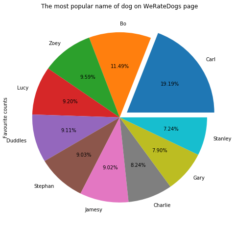

```python
name_and_favorite_count.head(10).plot(kind='pie' , autopct = '%1.2f%%',figsize = (8,8) , ylabel = 'Favourite counts' , title = 'The most popular name of dog on WeRateDogs page' , explode = explode);
```

- A dog called **"Carl"** have the most favourites in other names

#### Visualization #2:

#### The most popular dog breed

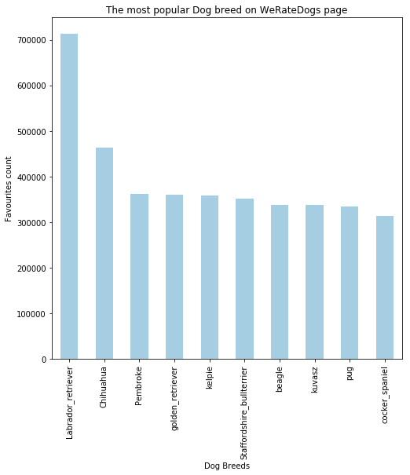

```python
twitter_archive_master.groupby('dog_breed')['favorite_count'].sum().sort_values(ascending = False).head(10).plot(kind = 'bar',xlabel = 'Dog Breeds' , ylabel = 'Favourites count', title = 'The most popular Dog breed on WeRateDogs page',figsize= (8,8)  ,colormap='Paired');
```

- The Labrador Retriever breed is the most popular dog breed

#### Visualization #3:

#### The most popular dog stage

```python
colors = [(0.1, 0.2, 0.5), (0.3, 0.6, 0.9)]
```

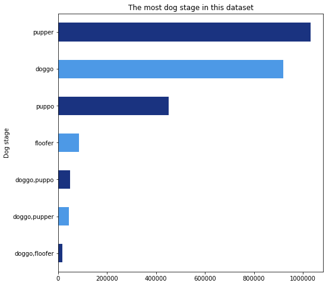

```python
twitter_archive_master.groupby('dog_stage')['favorite_count'].sum().sort_values(ascending = True).drop('Unknown').plot(kind = 'barh' , title = 'The most dog stage in this dataset' , xlabel= 'Dog stage' , figsize = (8,8) , color=colors);
```

- Pupper is the most popular dog stage in this dataset.